# Homework_2_Rino_Gwen

2. `geom_bar()` plots just one variable, showing the counts for each level as a bar graph. The height of each bar is proportional to the number of cases in each group. `geom_col()` plots a categorical variable x against a continuous variable y and shows the results as a bar graph. The height of the bars represents values in the data.

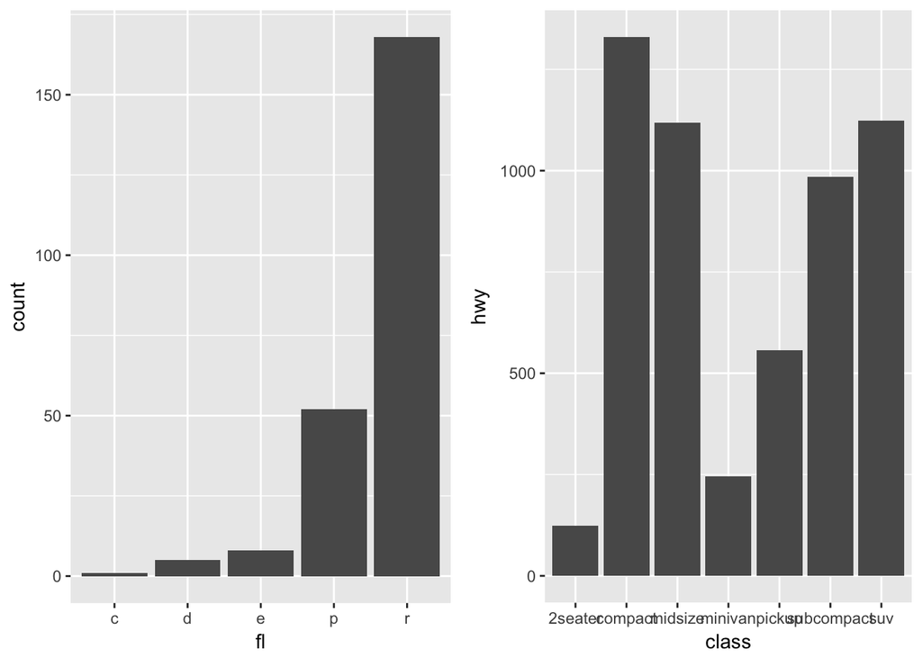

```r
p3 <- ggplot(mpg, aes(fl)) + geom_bar()

p4 <- ggplot(mpg, aes(class, hwy)) + geom_col()

grid.arrange(p3, p4, ncol = 2)
```

**Final Question**

Evaluation of data graphics at [What is a Data Scientist?](https://onlinelearning.berkeley.edu/courses/882865/files/folder/Session%202%20-%20Feb%206%202018?preview=60649489)

The first graphic, a pie chart showing somebody’s beliefs (we don’t know whose) about the demand for data scientists, is not a very effective visualization. The point, that there is high demand for data scientists, is not easy to discern. I would suggest a clearer title and a different kind of plot that makes the high demand for data scientists more apparent.

The second graphic, a bar graph showing the sources of new data talent, is much more effective. It is easy to read and interpret. I like that the bars are proportionally sized in width as well as height.

The third graphic, a chart showing the percentage of organizations that identify various obstacles to adopting data science, is reasonably effective. I like that the visualization includes progressive transparency for smaller and smaller percentages.

The fourth graphic is a faceted bar graph showing the level of education of data scientists compared to business intelligence professionals. I would suggest a much clearer title in order to increase the effectiveness of this visualization.

The fifth graphic uses proportionally-sized bubbles to show the areas of study of data scientists compared with business intelligence professionals. I think that this graphic is meant to emphasize in a positive way that data scientists have a wider range of academic backgrounds than BI professionals do, but when I look at the graphic my eye is drawn to the largest bubble, which denotes that 37% of BI professionals have a degree in business. Because my eye is drawn there, I am inclined to think that this means something positive. I don’t think the bubbles are the best means of visualizing the (desirable) diversity of backgrounds of data scientists compared with BI professionals.

The sixth graphic is a pie chart showing the proportion of data scientists who believe that their work makes more work for data scientists vs. those who do not believe this. I am interested to notice that a pie chart with only two levels is much easier to interpret than a pie chart with many levels. That said, I think that the title and labels of this visualization are a little confusing and could be improved.

The seventh graphic is a T-chart comparing the qualities of a “big data scientist” and a “normal data scientist”. In my opinion, “normal data scientist” is an unfortunate choice of title (since the opposite of “normal” is “abnormal”, and who wants to be associated with abnormality?). There is also a proportional bar below the T-chart showing (I think!) the percentage of data scientists who work in big data, “normal” data, or somewhere in the middle. Another possible meaning of this proportional bar is that a typical data scientist works 10% of the time in big data, 25% of the time in “normal” data science, and 65% of the time in the middle. I have to guess because there is no title or legend explaining this part of the visualization. I do like it that the proportional bar is organized in space in a meaningful way (with big data and “normal” data to the same sides as the T-chart, and “middle” in between).

The eighth graphic is a faceted bar graph, like the fourth graphic, showing the percentage of data scientists who work in various aspects of the data cycle compared with the percentage of BI professionals who do. It takes very careful inspection to understand that the blue bars represent BI professionals, and this is especially confusing because in the previous visualization blue was associated with “normal” data scientists. I would recommend that the colors be used consistently to represent the same group throughout. I would also recommend a clearer legend for this graphic.

The ninth and final graphic is extremely confusing. There are two titles, “Who does a data scientist work with?” and “Data science team.” There are a number of job titles and associated percentages. But the meaning of the numbers is impossible to discern. Do 36% of data science teams include a programmer? Do 36% of data scientists work with a programmer? Are 36% of the people on data science teams programmers? It is impossible to tell. This visualization needs to be completely overhauled in order to tell a clear story.